# QMSS G5072 Homework 8

Wenjun Sun

2019-11-16

# Writing a simple API client

### Choose your API

#### 1. Choose an API

##### a) Choose an API and briefly describe the type of data you can obtain from it.

The API I chose for this homework (and potentially for the final project) is [FBI Crime Data API](https://crime-data-explorer.fr.cloud.gov/api). It is said to be “broadly organized around the data reporting systems the FBI UCR program uses and their related entities”. [UCR program](https://www.fbi.gov/services/cjis/ucr/) stands for Uniform Crime Reporting (UCR) Program, it is consists of four data collections: The National Incident-Based Reporting System (NIBRS), the Summary Reporting System (SRS), the Law Enforcement Officers Killed and Assaulted (LEOKA) Program, and the Hate Crime Statistics Program.

##### b) Provide a link to the API documentation

Its documentation can be found at [this page](https://crime-data-explorer.fr.cloud.gov/api).

Besides, I found these two document about Incident-Based Reporting System (NIBRS) - [NIBRS Data Diagram](http://s3-us-gov-west-1.amazonaws.com/cg-d4b776d0-d898-4153-90c8-8336f86bdfec/nibrs_diagram.pdf) and [NIBRS Data Dictionary](http://s3-us-gov-west-1.amazonaws.com/cg-d4b776d0-d898-4153-90c8-8336f86bdfec/NIBRS_DataDictionary.pdf), they seems to be pretty helpful.

##### c) the base URL of the API you intend to use

The Crime Data Explorer Base API URL is https://api.usa.gov/crime/fbi/sapi/

#### 2. Authentication

##### a) Briefly explain how the API authenticates the user.

This API requires its users to have an API Key appended to the request.

##### b) Apply for an API key if necessary and provide the information (with relevant URL) how that can be done.

The API key can be obtained by signing up via https://api.data.gov/signup/. They will send the Key via email shortly after.

I already got the API key and saved it to my environment under the name FBICRIME_KEY.

#### 3. Send a Simple GET request

##### a) Execute a simple GET request to obtain a small amount of data from the API. Describe a few query parameters and add them to the query.

The FBI Crime API has many different sections, each of them has different parameters. Here, I will use ‘National level NIBRS Offender Demographic Count Endpoint’ as an example.

```r
baseurl <- 'https://api.usa.gov/crime/fbi/sapi'
```

The FBI Crime API is a directory-based on. For ‘NIBRS Offender Demographic data - National level NIBRS Offender Demographic Count’, it has 2 parameters: *offense* and *variable*.

- *offense* is the type of offense, which can be any one of ‘aggravated-assault’, ‘burglary’, ‘larceny’, ‘motor-vehicle-theft’, ‘homicide’, ‘rape’, ‘robbery’, ‘arson’, ‘violent-crime’, ‘property-crime’.
- *variable* is like a group_by option, which can be any one of ‘age’, ‘count’, ‘ethnicity’, ‘race’, ‘sex’.

The request should look like: [https://api.usa.gov/crime/fbi/sapi/api/nibrs/{offense}/offender/national/{variable}](https://api.usa.gov/crime/fbi/sapi/api/nibrs/%7Boffense%7D/offender/national/%7Bvariable%7D)

```r
desired_endpoint <- 'api/nibrs'
offense <- 'burglary'
variable <- 'race'
api_key <- paste('API_KEY=', Sys.getenv('FBICRIME_KEY'), sep = '')

query <- paste(baseurl, desired_endpoint, offense, 'offender', 'national', variable,
               sep = '/')

endpoint <- paste(query, '?', api_key,
                  sep = '')

GET(endpoint)
```

```
## Response [https://api.usa.gov/crime/fbi/sapi/api/nibrs/burglary/offender/national/race?API_KEY=wJVwagUO01YEnQVabvFNzHTX22FOonTJGAmYSOCt]
##   Date: 2019-11-17 03:36
##   Status: 200
##   Content-Type: application/json;charset=UTF-8
##   Size: 17.4 kB
## {
##   "ui_type" : "basic_table",
##   "noun" : "Offender",
##   "category" : "Offender demographic",
##   "title" : "Offender Race",
##   "short_title" : "Race",
##   "ui_restriction" : null,
##   "keys" : [ "Asian", "Native Hawaiian", "Black or African American", "A...
##   "data" : [ {
##     "value" : 1246,
## ...
```

```r
response <- GET(endpoint)
```

##### b) Check the status of the request (using `http_status`).

```r
http_status(response)
```

```
## $category
## [1] "Success"
##
## $reason
## [1] "OK"
##
## $message
## [1] "Success: (200) OK"
```

http_status returns Success: (200) OK, looking good.

##### c) Check the type of the response (e.g. XML, JSON, csv using `http_type`).

```r
http_type(response)
```

```
## [1] "application/json"
```

The type of the response is JSON.

#### 4. Parse the response and Create a dataset

##### a) Take the response returned by the API and turn it into a useful R object (e.g. a list, vector, or data frame). Show the code how this is done.

```r
content <- content(response)
df <- as.data.frame(fromJSON(toJSON(content$data), simplifyDataFrame = TRUE))

df %>% select('data_year', 'key', 'value') %>%
       arrange(desc(as.numeric(data_year)), as.character(key)) %>%
       head(20) %>%
       kable() %>%
       kable_styling(bootstrap_options = "striped")
```

| data_year | key | value |
| --- | --- | --- |
| 2018 | American Indian or Alaska Native | 2170 |
| 2018 | Asian | 1444 |
| 2018 | Black or African American | 55759 |
| 2018 | Native Hawaiian | 0 |
| 2018 | Unknown | 111786 |
| 2018 | White | 118828 |
| 2017 | American Indian or Alaska Native | 2405 |
| 2017 | Asian | 1071 |
| 2017 | Black or African American | 55888 |
| 2017 | Native Hawaiian | 0 |
| 2017 | Unknown | 102044 |
| 2017 | White | 122865 |
| 2016 | American Indian or Alaska Native | 2107 |
| 2016 | Asian | 1056 |
| 2016 | Black or African American | 56870 |
| 2016 | Native Hawaiian | 0 |
| 2016 | Unknown | 95666 |
| 2016 | White | 124682 |
| 2015 | American Indian or Alaska Native | 1848 |
| 2015 | Asian | 1014 |

##### b) Using the API, create a dataset (in data frame format) for multiple records.

For this question, I no longer limit the type of crime to burglary, i.e. I will go over all kinds of offense, and return a dataframe with four columns: year, type (type of offense), race, count.

```r
# this chunk is actually unnecessary, because all the code is from the above chunks, but I re-wrote them here as a reminder

baseurl <- 'https://api.usa.gov/crime/fbi/sapi'
desired_endpoint <- 'api/nibrs'
variable <- 'race'
api_key <- paste('API_KEY=', Sys.getenv('FBICRIME_KEY'), sep = '')
```

```r
offense_type <- c('aggravated-assault', 'burglary', 'larceny', 'motor-vehicle-theft', 'homicide', 'rape', 'robbery', 'arson', 'violent-crime', 'property-crime')

df_result <- data.frame(matrix(ncol = 4, nrow = 0))
colnames(df_result) <- c('year', 'type', 'race', 'count')


for (offense in offense_type) {
  query <- paste(baseurl, desired_endpoint, offense, 'offender', 'national', variable,
                 sep = '/')
  endpoint <- paste(query, '?', api_key,
                    sep = '')
  response <- GET(endpoint)
  content <- content(response)
  df <- as.data.frame(fromJSON(toJSON(content$data), simplifyDataFrame = TRUE))
  df <- df %>%
        mutate(year = as.numeric(data_year), type = offense, race = as.character(key), count = as.numeric(value)) %>%
        select(year, type, race, count)
  df_result <- rbind(df_result, df)
}

df_result %>% arrange(desc(year), type, race) %>%
              head(20) %>%
              kable() %>%
              kable_styling(bootstrap_options = "striped")
```

| year | type | race | count |
| --- | --- | --- | --- |
| 2018 | aggravated-assault | American Indian or Alaska Native | 3469 |
| 2018 | aggravated-assault | Asian | 2465 |
| 2018 | aggravated-assault | Black or African American | 100786 |
| 2018 | aggravated-assault | Native Hawaiian | 0 |
| 2018 | aggravated-assault | Unknown | 18421 |
| 2018 | aggravated-assault | White | 127954 |
| 2018 | arson | American Indian or Alaska Native | 88 |
| 2018 | arson | Asian | 79 |
| 2018 | arson | Black or African American | 1907 |
| 2018 | arson | Native Hawaiian | 0 |
| 2018 | arson | Unknown | 2334 |
| 2018 | arson | White | 5362 |
| 2018 | burglary | American Indian or Alaska Native | 2170 |
| 2018 | burglary | Asian | 1444 |
| 2018 | burglary | Black or African American | 55759 |
| 2018 | burglary | Native Hawaiian | 0 |
| 2018 | burglary | Unknown | 111786 |
| 2018 | burglary | White | 118828 |
| 2018 | homicide | American Indian or Alaska Native | 46 |
| 2018 | homicide | Asian | 44 |

##### c) Provide some summary statistics of the data. Include the data frame in a .RDS file (using `saveRDS`) called `data.rds` with your submission for the grader.

I aggregated the previous dataframe by year and race, it returns the total number of offense of each race by year.

In addition, I plotted a line graph for each race over year. I noticed that Asian have some unusual high amount of offense in 1990s, which is strange given the proportion of Asian in the US is only about 5%. I went back to the FBI CRIME API website and rechecked, the number is the same when I mannually do the search on their website. So I think there should be something wrong with the raw data.

```r
df_summary <- df_result %>%
              group_by(year, race) %>%
              summarise(total = sum(count))

saveRDS(df_summary, file = 'FBI_crime_offender_summary.RDS')
```

The summary table (I only display the top 10 rows here) and visualizationn.

```r
df_summary %>%  head(10) %>%
                kable() %>%
                kable_styling(bootstrap_options = "striped")
```

| year | race | total |
| --- | --- | --- |
| 1991 | American Indian or Alaska Native | 1290 |
| 1991 | Asian | 173254 |
| 1991 | Black or African American | 176192 |
| 1991 | Native Hawaiian | 0 |
| 1991 | Unknown | 318780 |
| 1991 | White | 111802 |
| 1992 | American Indian or Alaska Native | 3052 |
| 1992 | Asian | 299674 |
| 1992 | Black or African American | 178722 |
| 1992 | Native Hawaiian | 0 |

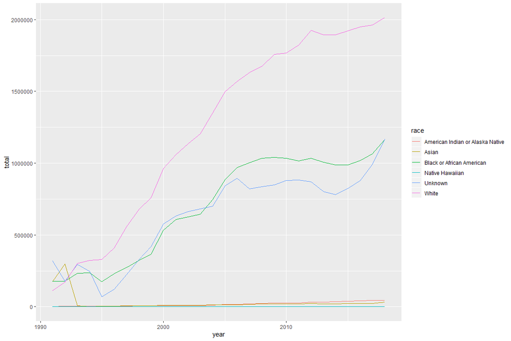

```r
df_summary %>% ggplot(aes(x = year, y = total, group = race, colour = race)) +
               geom_line()
```

#### 5. API Client

Lastly, let’s try to wrap the code from the previous sections into a simple API client function.

The function FBI_offender gets the national level NIBRS offender demographic information. It has two parameters, *offense* and *variable*.

- *offense* is the type of offense, which can be any one of ‘aggravated-assault’, ‘burglary’, ‘larceny’, ‘motor-vehicle-theft’, ‘homicide’, ‘rape’, ‘robbery’, ‘arson’, ‘violent-crime’, ‘property-crime’.
- *variable* is like a group_by option, which can be any one of ‘age’, ‘count’, ‘ethnicity’, ‘race’, ‘sex’.

```r
FBI_offender <- function(offense = 'arson', variable = 'count'){
  baseurl <- 'https://api.usa.gov/crime/fbi/sapi'
  desired_endpoint <- 'api/nibrs'
  api_key <- paste('API_KEY=', Sys.getenv('FBICRIME_KEY'), sep = '')

  query <- paste(baseurl, desired_endpoint, offense, 'offender', 'national', variable,
                 sep = '/')
  endpoint <- paste(query, '?', api_key,
                    sep = '')
  response <- GET(endpoint)

  if(http_error(response)){warning("The request produced an error.")}
  else {content <- content(response)}

  df <- as.data.frame(fromJSON(toJSON(content$data), simplifyDataFrame = TRUE))
  df <- df %>%
        mutate(year = as.numeric(data_year), type = offense, variable = as.character(key), count = as.numeric(value)) %>%
        select(year, type, variable, count) %>%
        arrange(desc(year), type)

  return(df)
  }

FBI_offender_default <- FBI_offender()
saveRDS(FBI_offender_default, file = 'api_client_output.RDS')
```